## FAIRbioinfo for bioinformaticians

#### Introduction to the tools of reproducibility in bioinformatics

#### C. Hernandez^1 T. Denecker^1 J. Sellier^2 G. Le Corguill ́e^2

#### C. Toffano-Nioche^1

(^1) Institute for Integrative Biology of the Cell (I2BC) UMR 9198, Universit ́e Paris-Sud, CNRS, CEA 91190 - Gif-sur-Yvette, France (^2) IFB Core Cluster taskforce

#### Sept. 2020

# Introduction to code versioning

## Really need of a files history?

> “Most researchers are primarily collaborating with themselves,” Tracy Teal explains. “So, we teach it from the perspective of being helpful to a ‘future you’.”

[figure not shown]

## Files history = good practice for reproducible research

> ”Rule 4: Version Control All Custom Scripts”

[figure not shown]

## Version control

### Definition

version control, revision control, source control, or source code management: class of systems responsible for managing changes to files.

### Feature

Each revision is associated with a timestamp and the person making the change. Revisions can be compared, restored, and merged.

### Software

SVN, Git, Mercurial, GNU arch, etc

[wikipedia](https://en.wikipedia.org/wiki/Version_control)

### Revisions graph

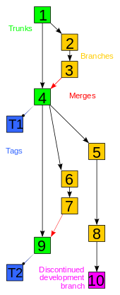

img3

## Git and GitHub

### Git

- will track and version your files
- enables you to collaborate with … yourself
- open source license GPL (GNU General Public License)
- created in 2005 by Linus Torvalds for the development of the Linux kernel

### GitHub

- stores your repositories online
- enables you to collaborate with others (and yourself)
- first commit in 2007 by Chris Wanstrath, founded in feb. 2008, Microsoft Corporation still 2018

# Git

## Concepts, objects

- working directory: a user private copy of a whole repository of interest
- staging area: list of files of the working directory that will be considered for next commit (ie. could be not all the modified files)
- clone: a local copy of a repository (include all commits and branches), the original repository can be local, or remote (http access)
- commit: a git object, the snapshot of your entire repository compressed into a SHA (also the command the saves changes by creating the snapshot)
- HEAD: pointer representing your current working directory. Can be moved (git checkout) to different branches, tags, or commits
- branch: a lightweight movable pointer to a commit
- merge: combines remote tracking branches into current local branch

[Tuto git 1](https://www.tutorialspoint.com/git/git_quick_guide.htm)

[Tuto git 2](https://www.powershellmagazine.com/2015/07/13/git-for-it-professionals-getting-started-2/)

## Setup

### Git configuration: if not yet done, tell git our identity

```
git config --global user.name <Your Name>
git config --global user.email <Your Email>
```

### Git repository initialisation

The initialisation (red arrow) is the creation of a .git repository:

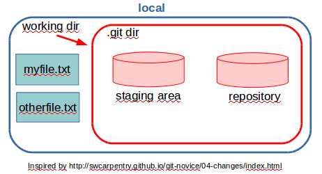

img4

3 ways to initialize a .git repository:

```
# inside an existing folder (possibly containing files)
git init
# create the folder ”myproject” +  initializes the .git subfolder inside it
git init <myproject>
# copy the existing git repository to
git clone </gitfolder/path> </new/path>
```

### Tracking file

git add and then commit commands for myfile.txt :

```
git add <myfile.txt>
git commit -m <"my reason">
```

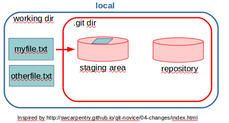

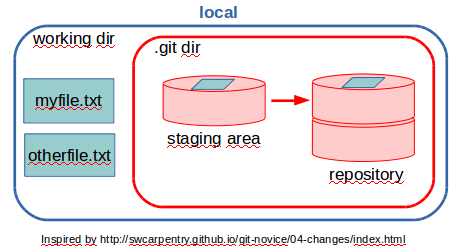

[source](http://swcarpentry.github.io/git-novice/fig/git-staging-area.svg)

### Git file states

Checking the file status:

```
git status
```

File goes from untracked to tracked state (init), unstaged to staged state (add) and finally, to a committed state (commit).

# Git Exercise

## Objective

### 1st exercise

- access and configure git
- initialize a git repository
- create files in this repository
- use the basic git commands for tracking files changes (status, add, commit)

### 2nd exercise

- copy another repository from github (clone)
- use branching (branch) and merging (merge) to manage code changes

## Setup: objectives 1 & 2

### Git access by doker

```
docker run -i -t -v "${PWD}":/data continuumio/miniconda
```

### Git configuration

Global configuration (checkinguser.namewith:git config –list):

```
git config --global user.name ’Your Name’
git config --global user.email ’Your Email’
```

### Git repository initialization

On a new dedicated folder run:

```
git init # observe the .git folder (ls -la)
git status # find the current branch , "nothing to commit"
```

## adding files: objective 3

### create 2 files, check their git status: obj

```
for i in 1 2 ; do echo "file"${i}" text" > file${i}.txt ;
done
git status # observe list of untracked files
```

### add file1 to stating area

```
git add file1.txt
git status # observe the changing status of file1: untracked => staged
```

### change file1 text

```
sed ’s/text/text change/’ file1.txt > tmp ; mv tmp file1.txt
git status # observe the 3 states , why file1 appears in "to be commited" and also in "not staged for commit "?
```

## commit: objective 4

### stage all files

```
git add file1.txt file2.txt # all files
git status
```

### commit

```
git commit -m "1st commit + file1 change" # always add a message , use present time to explain the change
git status # all ok
```

So far, we have initiated a new project whose code is versioned by git: we have created files and all their successive changes were saved thanks to git.

We will now create a 2nd project by copying an already existing one. We’re going to bring this project from an online git project site,e.g. github.

## cloning: objective 5

### copy of a project: clone

To download a project from github, we use the gitclonecommand:

[output not shown]

[output not shown]

git branch # find the star

[output not shown]

[output not shown]

### return to master branch

```
git checkout master
more README.md # Is README.md modified or initial version?
```

## merging branch: objective 6

We have check that our change is valid, so we now plan to move it into the master branch.

### merge branch, then delete branch

[output not shown]

# GitHub

## ”Who”?

### Quizz

- public institute (governmental)?
- semi-public institute?
- not-for-profit organisation?
- private company?

### Response

[See](https://github.com/about): Careers’ paragraph, you’ll see a ”company” word

## GitLab, a Github alternative?

## “What”?

### Quizz

- social network?
- desktop application?
- tool to create websites?
- stable repository to publish any file?

### a social network

[figure not shown]

### a desktop application

[figure not shown]

### a tool to create websites

[figure not shown]

### a stable repository …

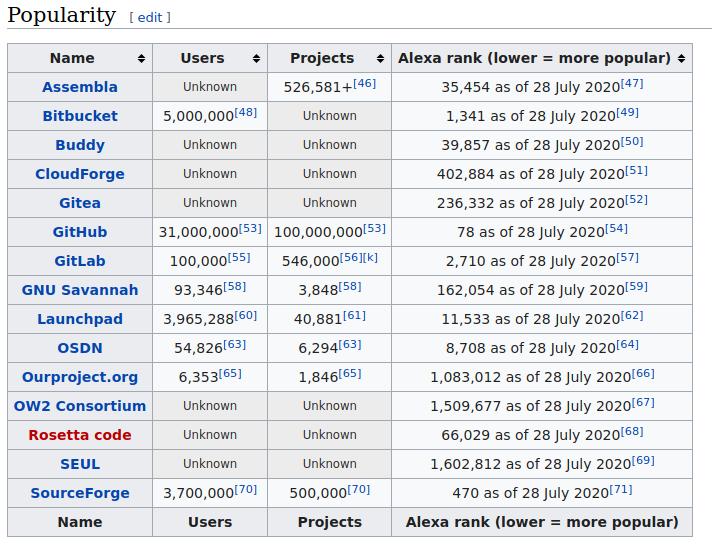

## … to publish any file

Files for which git can calculate the difference between versions.

Usually txt files of reasonable size:

- R script: YES
- Python script: YES
- pdf file: NO
- fastq file: NO

# GitHub: main usage: sharing code with others

## GitHub

- so used that Microsoft was interested in it (boughtin june 2018)
- web-based: graphical interface + many more features than git
- git-based: git concepts and commands are retained
- commands for ”sharing”:git push origin master(local to remote) andgit pull origin master(remote to local):

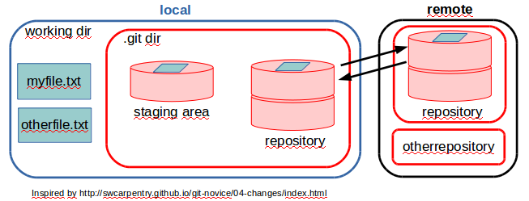